# TP1 - Feedback

### Parte I - A:

Se generaron 3 funciones de lectura de datos:

- raw_read_bci_csv: que lee el csv de los datos (sin los metadatos innecesarios pero con todas las columnas).
- clean_read_bci_csv: que lee el csv de datos, elimina columnas innecesarias y genera una columna con el tiempo correcto.
- add_sub_label: Taggea cada intervalo de cada tipo de estado.

Cargamos un dataset de una sessión (AA-1 por ejemplo)

Se leen los datos al mismo tiempo que se eliminan las columnas y filas innecesarias:

|  | ch0 | ch1 | ch2 | ch3 | label | time |
| --- | --- | --- | --- | --- | --- | --- |
| 0 | 2081.61 | 994.82 | 2229.93 | 1975.38 | 99 | 0.000 |
| 1 | 1926.57 | 836.23 | 2065.95 | 1912.34 | 99 | 0.005 |
| 2 | 1744.17 | 650.03 | 1852.65 | 1883.84 | 99 | 0.010 |
| 3 | 1937.29 | 848.86 | 2050.07 | 1970.17 | 99 | 0.015 |
| 4 | 2079.86 | 980.78 | 2222.84 | 1981.65 | 99 | 0.020 |

Se identifica cada intervalo de cada etiqueta presente en cada registro:

|  | ch0 | ch1 | ch2 | ch3 | label | time | sub_label |
| --- | --- | --- | --- | --- | --- | --- | --- |
| 0 | 2081.61 | 994.82 | 2229.93 | 1975.38 | 99 | 0.000 | 99-0 |
| 14989 | 1856.34 | 814.71 | 1963.03 | 1954.19 | 2 | 74.945 | 2-0 |
| 17093 | 1986.53 | 952.88 | 2130.14 | 1976.00 | 99 | 85.465 | 99-1 |
| 18142 | 2017.35 | 994.21 | 2184.45 | 1935.56 | 1 | 90.710 | 1-0 |
| 20242 | 1890.33 | 861.54 | 2029.52 | 1914.82 | 99 | 101.210 | 99-2 |
| 21833 | 1986.90 | 941.09 | 2138.30 | 1918.83 | 2 | 109.165 | 2-1 |
| 23937 | 1982.25 | 948.23 | 2098.49 | 1979.82 | 99 | 119.685 | 99-3 |
| 24978 | 2027.26 | 1004.76 | 2194.41 | 1927.02 | 1 | 124.890 | 1-1 |
| 27079 | 1909.15 | 885.34 | 2031.91 | 1973.02 | 99 | 135.395 | 99-4 |
| 29386 | 1973.86 | 948.29 | 2091.14 | 1984.26 | 2 | 146.930 | 2-2 |

### Parte I - B:

```
array(['MA', 'JA', 'AA', 'HA'], dtype=object)
```

```
AA    3
JA    2
MA    1
HA    1
Name: subject, dtype: int64
```

Para la parte I se decide trabajar todos los registros en un sólo dataframe. Hay 4 pacientes: 'MA', 'JA', 'AA', 'HA' 'MA' y 'HA', con una session de adquisición, 'JA' con 2 y 'AA' con 3

### Parte I -C:

No todas las columnas son relevantes:

- Las columnas de los acelerómetros no contienen información, se descartan.
- La columna de timestamp y tiempo provisto, tienen problemas de adquisición (poca sensibilidad en la medición) y noresulta del todo explicativa, se la reemplaza por una nueva columna de tiempos.
- La columna de número de muestras se reemplaza por una cuenta global a lo largo del registro, en vez de cada 201 mustras.

El registro no presenta datos nulos, el análisis de valores atípicos es realizado en los próximos puntos.

Los 200Hz se traducen en 200 muestras por segundo, esta información fue usada para generar la columna de tiempo en el dataframe "limpio".

Se presentan los siguientes tipos de datos por canal, se revisa que las columnas object contengan sólo string y no datos corruptos:

```
ch0 float64
ch1 float64
ch2 float64
ch3 float64
label int64
time float64
sub_label object
subject object
session object
sub_sess object
```

### Parte I-D:

Si graficamos todos los canales para el sujeto 'MA' en la sesion 1:

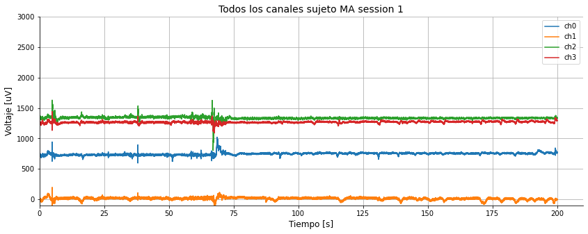

Se puede ver que cada canal tiene un offset y una componente lineal distinta. Se puede ver también que hay fenómenos que se repiten a lo largo de los diferentes calaes (ej: 70s)

Si gradicamos todos los registros del canal 0 de todos los sujetos y todas las sesiones:

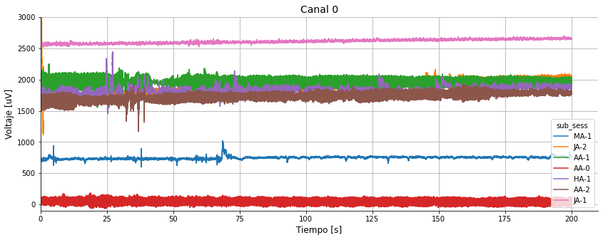

Se puede observar que hay gran variabilidad no sólo entre sujetos sino también entre sesiones. Hay variabilidad en el offset, pero también en la componente lineal y en los rangos de valores que puede adoptar la señal.

Si graficamos un canal para un mismo sujeto en diferentes sesiones:

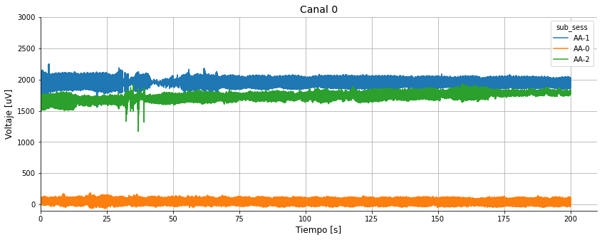

Aquí se refuerza lo antes dicho, hay gran variabilidad de offset, componente lineal (tendencia) y rango de valores que adopta la señal.

Si graficamos todos los estados en un mismo canal para una sesion y un sujeto:

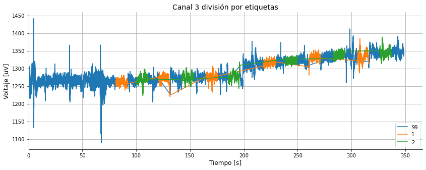

Podemos ver que a simple vista, ni el offset, ni la tendencia, ni la variabilidad de la seña tienen un correlato con la etiqueta presente. Quizás los intervalos 99 son más propensos a valores extraños.

Si observamos todos los tramos de la etiqueta 2 en el canal cero, para todos los pacientes y todas las sesiones:

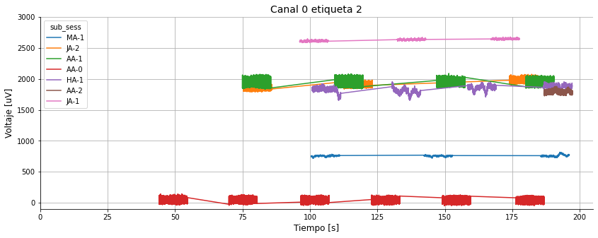

Nuevamente es claro que el valor de voltaje no representa una regularidad para cada uno de los estados en los diferentes registros

Hasta acá lo que prima es la gran variabilidad de los valores que puede adoptar la señal, independientemente del sujeto, y de la sesion de adquisición.

## PARTE II

### Parte II-A:

Se selecciona el sujeto 'MA', sesion 1, canal 3

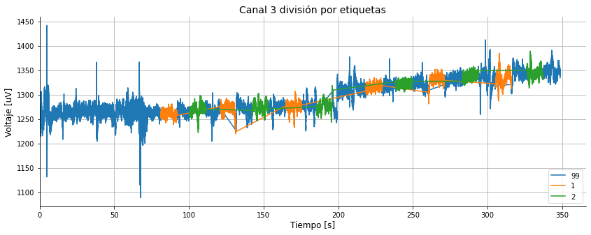

Se grafica el histograma de los valroes de voltajes agrrupados por etiqueta:

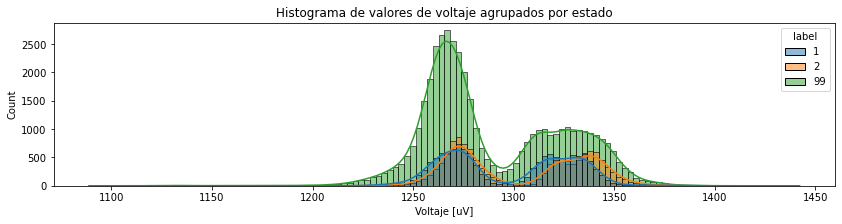

Se puede observar que los tres estados tienen histgramas muy solapados, si los estudiamos en relación a los graficos en función del tiempo, podemos ver que la bimodalidad aproximada que tienen los datos puede deberse a la componente lineal que tiene la señal.

Para ver este fenómeno más claramente, se grafican los histogramas de los valores de voltaje para cada estado por separado. En cada gráfico se identifican con diferentes colores cada uno de los intervalos de esa etiqueta que hay en el registro:

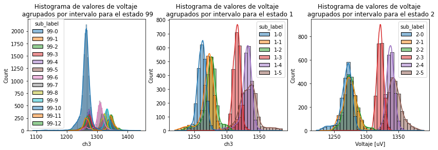

Se evidencia que cada intervalo tiene una distribución unimodal similar a una gaussiana, sin embargo producto de la deriva (componente lineal) y el offset, el valor central en cada intervalo varía.

Se propone corregir el offset y la componente lineal, mediante la estimación de una regresión lineal sobre una ventana de tiempo para cada canal. Se prueban dos opciones de corrección, una usando el total de la señal, y una segunda usando ventanas de 10 segundos. Como a simple vista se puede ver que la tendencia no es del todo lineal sino pacere hacer algun tipo de tendencia polinómica, se cree que hacerlo por tramos es una mejor opción.

Si bien uno podría hacer una corrección a lo largo de cada intervalo de cada estado, si uno luego quiere clasificar esas señales y si uno lo quisiera hacer en el dominio del tiempo estaría metiendo un bias. En este habría una variable (offset y componente lineal) que podría llegar a tener algo en común entre intervalos de un mismo estado, pero que por conocimiento de dominio sabemos que no es una variable discriminativa.

La herramienta dtrend de scipy no hace más que restar una regresión lineal a nuestros datos: https://docs.scipy.org/doc/scipy/reference/generated/scipy.signal.detrend.html

Si graficamos las señales con y sin corrección de componente lineal:

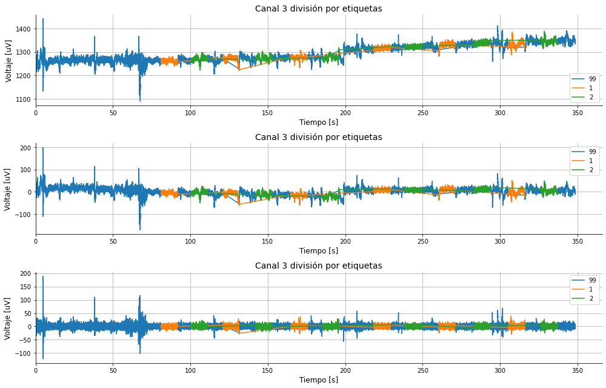

En el gráfico anterior se ve una comparativa entre: la señal sin corregir, la señal con una eliminación de la componente lineal realzado sobre el total de la señal y en el último de los casos con una eliminación de la tendencia local. Se continúa el trabajo, con la señal con el detrend local.

### Parte II-A

Para analizar la distribución de los datos en cada etiqueta se grafican los histogramas correspondientes:

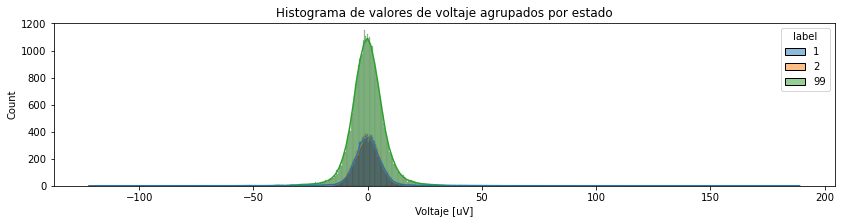

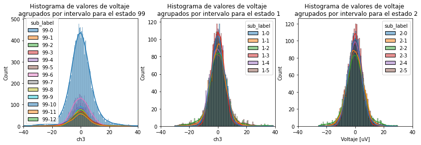

Ahora podemos observar que los valores de voltaje pasan a tener una distribución practicamente normal en torno a cero. La corrección de la tendencia ha sido exitosa.

Para seguir trabajando, nos quedamos con las señales correspondientes al primer intervalo de cada etiqueta presente en el registro. Gráfico en el dominio del tiempo:

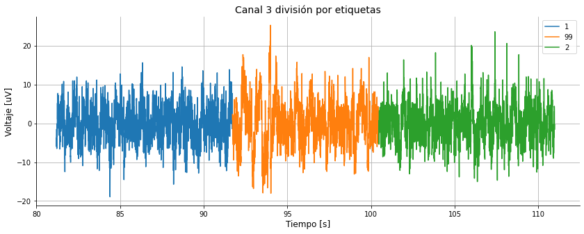

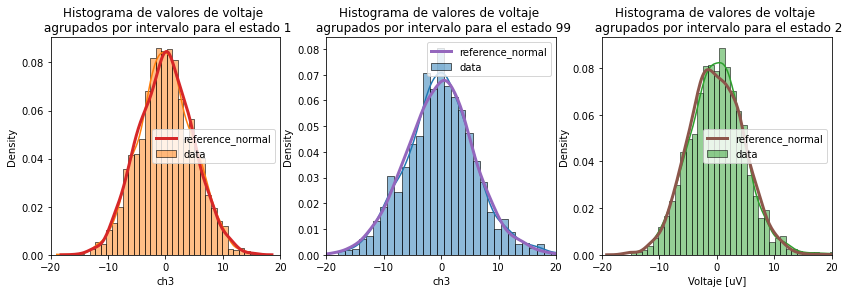

```
Normal test for state 1, p-value: 0.8276724529142978
Normal test for state 99, p-value: 8.906686108552214e-05
Normal test for state 2, p-value: 2.57004866872616e-11
```

Si bien podemos ver por los valores del p-valor de los tests que dos de las distribuciones de los datos no se corresponderían con una normal, una inspección gráfica nos muestra que los datos tienen una distribución unimodal, casi sin lateralidad que se parece mucho a la distribución normal con la misma desviación estandar que los datos (segunda fila). El motivo del rechazo de la hipótesis nula puede ser la alta sensibilidad del test, en donde quizás algún peso mayor en las colas de la distribución empírica la aleje de una normal estricta. A fines prácticos se la considera normal.

Resumen estadístico:

|  | 99 | 1 | 2 |
| --- | --- | --- | --- |
| mean | -0.036392 | 0.057471 | -0.011986 |
| median | -0.039559 | -0.044955 | -0.046308 |
| std | 6.073089 | 4.774755 | 4.879582 |
| mode | 0.0 | -1.0 | 1.0 |
| min | -18.018318 | -18.924439 | -15.023763 |
| max | 25.250788 | 15.600685 | 23.580716 |

La coincidencia de la media moda y mediana refuerza la hipótesis de la normalidad de los datos. Se elige la media y la desviación estandar como indicadores de centralidad y dispersión. Se puede ver que el intervalo de ruido (99) tiene una mayor disperisón.

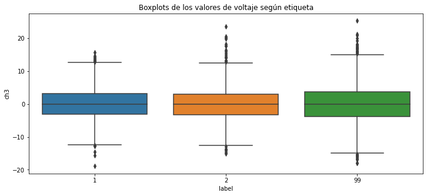

Se pueden ver que según el criterio de tomar 1.5 veces el rango intercuartílico se pueden definir valores outliers. El problema en este caso es definir cómo reemplazar esos datos se define la media entre los dos valores aledaños. Como no se seguirá trabajando en el resto de los prácticos con este dominio, y como no son outliers muy groseros, se conservan por ahora.

```
p-value for t-test comparing the means of label 1 vs label 2: 0.640762799539858
p-value for t-test comparing the means of label 1 vs label 99: 0.5913664831114263
p-value for t-test comparing the means of label 2 vs label 99: 0.890067797460492
```

Se puede ver que no se puede descartar la hipótesis nula que indica que las medias son iguales. Es decir no tenermos uns diferencia estadísticamente significativa entre las medias de los estados a esta esacala.

Resumen y conclusiones:

- Los datos tiene artefactos de adquisición que hacen que aparezcan offsets y componentes lineales. Si no se limpian adecuadamente los datos la variabilidad del problema resulta abrumadora.
- Al limpiar los datos, se puede ver cómo los valores de voltaje a lo largo del tiempo, tienen una distribución practicamente normal, con media cero (producto de la corrección con el detrend lineal).
- Entre los estados no hay una diferencia significativa en el valor medio del voltaje, sí se da un ligero aumento de la dispersión de los valores cuando el estado se corresponde con la etiqueta 99, lo cual tiene sentido ya que en ese estado no hay una concetración/tarea puntual, así que puede ser más ruidosa la señal.

### PARTE II-B

Se vuelve a repetir el análisis realizado anteriormente pero ahora para todos los datos de cada etiqueta presentes a lo largo de todo el registro:

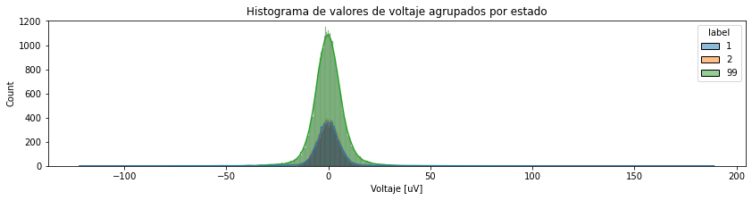

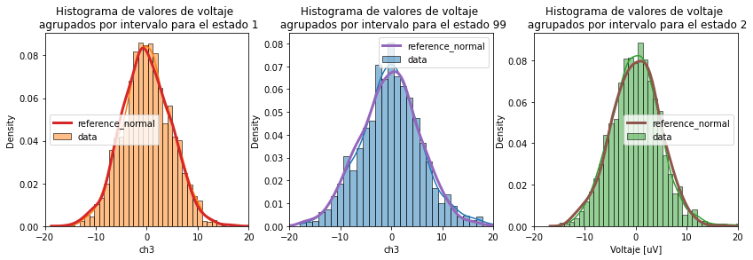

Testeamos la normalidad de las distribuciones para cada estado:

```
Normal test for state 99, p-value: 8.906686108552214e-05
Normal test for state 1, p-value: 0.8276724529142978
Normal test for state 2, p-value: 2.57004866872616e-11
```

Resumen estadístico:

|  | 99 | 1 | 2 |
| --- | --- | --- | --- |
| mean | -0.036392 | 0.057471 | -0.011986 |
| median | -0.039559 | -0.044955 | -0.046308 |
| std | 6.073089 | 4.774755 | 4.879582 |
| mode | 0.0 | -1.0 | 1.0 |
| min | -18.018318 | -18.924439 | -15.023763 |
| max | 25.250788 | 15.600685 | 23.580716 |

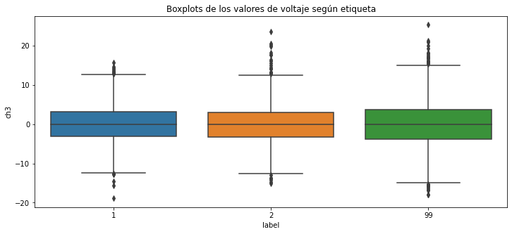

Test comparativos de medias

```
p-value for t-test comparing the means of label 1 vs label 2: 0.9263689686198546
p-value for t-test comparing the means of label 1 vs label 99: 0.8950491892618568
p-value for t-test comparing the means of label 2 vs label 99: 0.9600373266535347
```

Resumen y Conclusión:

- El análisis refleja resultados muy similares y consistentes con lo observado en a nivel de intervalos. Los valores de voltaje no parecieran sr discriminativos para estos estados.

### PARTE II-C

Graficamos las señales sin corregir y corregidas:

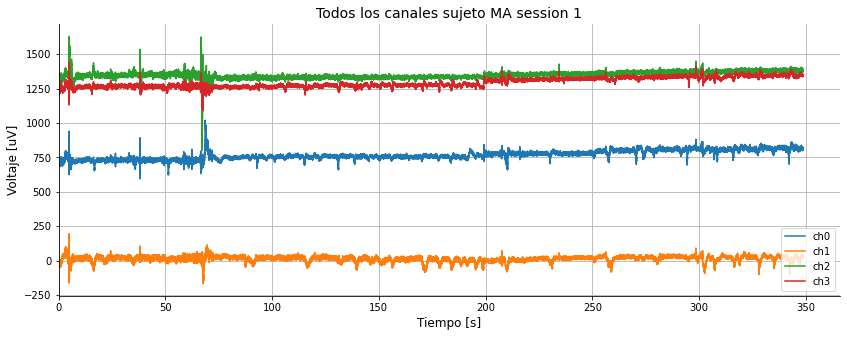

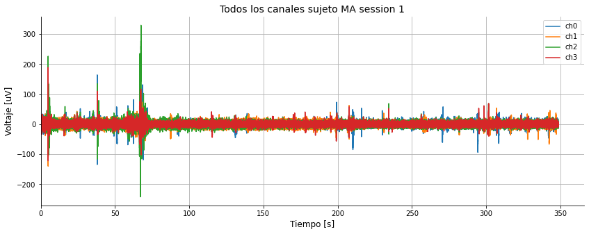

De la observación del gráfico de línea, se puede ver que cuando un canal tiene un abrupto la mayoría lo repiten, o inclusive cuando un canal tiene un pico también pareciera repetirse en el resto. Esto indica que podría haber una correlación.

Para estudiar cuantitativamente la correlación entre los canales se calcula la correlación de Pearson entre canales y se presentan en una matriz de doble entrada.

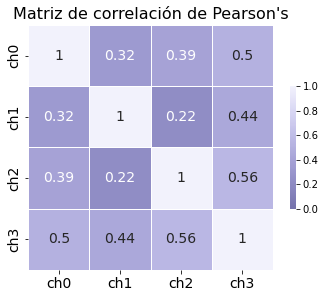

Se puede ver que algo de correlación hay, pero no llega a ser tan marcada, quizás entre el canal 2 y 3 sea relevante. Estos resultados no se llegan a apreciar en el pairplot siguiente.

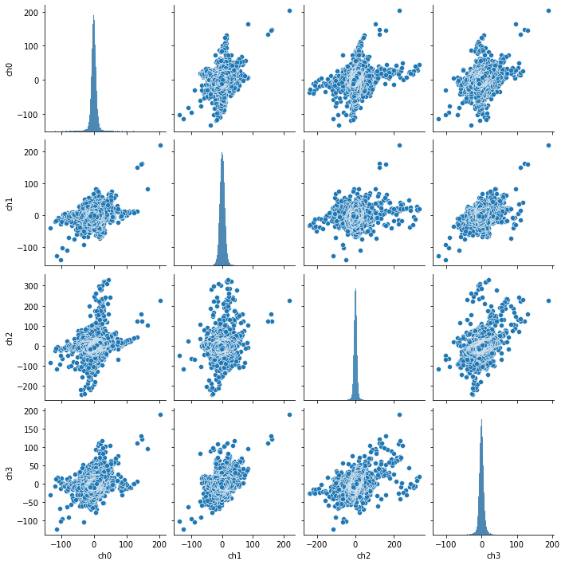

Si bien existe algo de correlación, esta no es tan pronunciada, por lo que si bien hay información superpuesta entre los canales, no se podría afirmar con certeza que alguno de los canales sea redundante. Por esto no se recomienda descartar ninguno de ellos.

Análisis comparativo de las distribuciones de los datos a lo largo de los canalaes para cada una de las diferentes etiquetas:

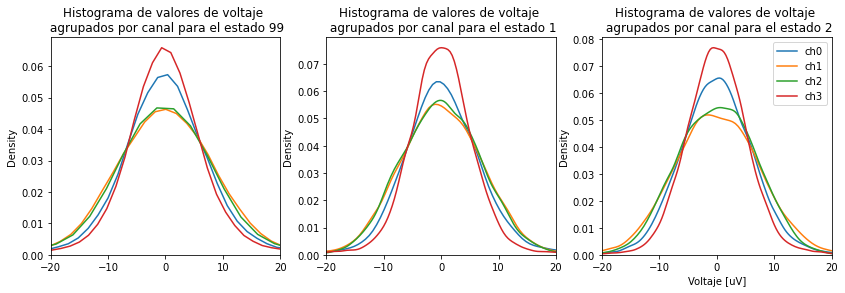

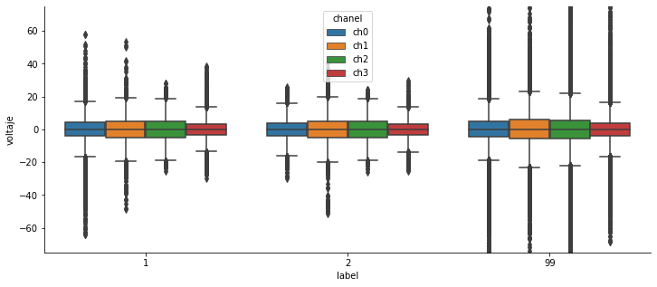

Conclusiones:

- Se puede ver que los valores de voltaje tienen una ligera correlación a lo largo del tiempo. Debido a la limpieza realizada sobre los datos, esta correlación no debería deberse a la deriva o componentes lineales.
- Sin embargo, dado que las correlaciones no llegan a ser muy importantes, y por lo antes dicho, se decide seguir trabajando con el total de los canales para cada paciente.
- Al analizar los valores de voltaje para cada etiqeuta para cada paciente, se puede ver cómo para un mismo estado cada canal presenta diferentes dispersiones en los voltajes y las medias siempre se mantienen iguales (producto del detrending). Por estas razones no hay un indicador claro en los valores de voltaje per sea constante a lo largo de los canales y que permita diferenciar los estados.

### Parte II-D:

A juzgar por los resultados obtenidos en los análisis previos, los gráficos de caja resultan un buen resumen a la hora de comparar la distribución de los valores de coltaje en cada etiqueta/canal/sesion/sujeto. Se usa ese gráfico para comparar los valores de voltaje, a lo largo de los diferentes canales, para cada uno de los registros presentes en el dataset, generando un gráfico por etiqueta:

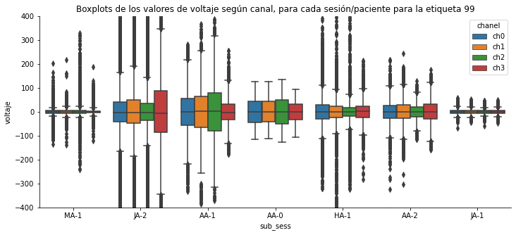

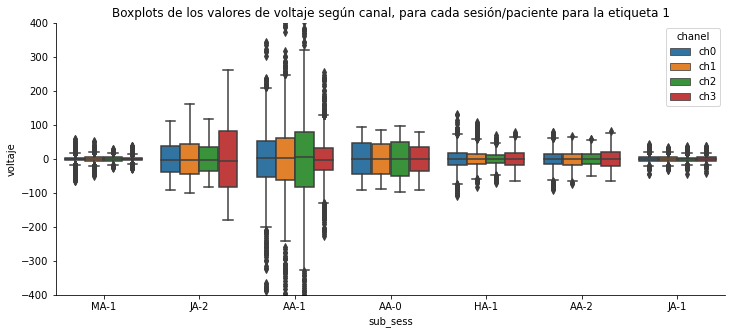

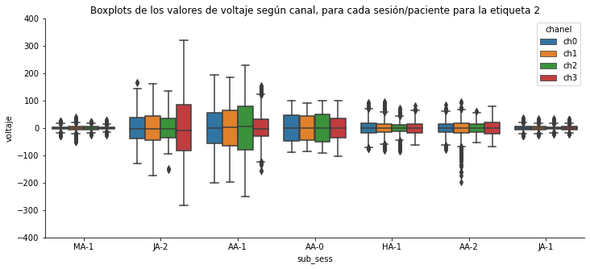

Aquí podemos ver que si bien todos los estados tienen una media cercana a cero, se tiene una gran variabilidad a lo largo de los sujetos y sesiones.

Se puede ver que hay sesiones (AA-1) con muchos outliers a lo largo de todos los canales que habría que estudiar en detalle para determinar si no corresponde eliminar ese registo.

### Conclusiones generales:

- No se evidencia que los valores de amplitud de los registros tengan un correlato con el estado/etiqueta.
- Los valores de voltaje, una vez corregida la deriva de los electrodos, presentan una distribución normal o muy cercana a ella. La media de esta variable es cero o muy cercana a cero, pero la desviación estándar es una variable que depende de cada sesión, sujeto y canal, sin relaciones claras o uniformes para cada uno de los estados/etiquetas.
- El análisis en el dominio del tiempo no parece contener información que permita una diferenciación evidente y clara de los estados. Más bien se presentan muchas complejidades y particularidades de cada sujeto/registro, que vuelven el análisis poco generalizable.